# Behavioral analyses

# Setup

```r
workflow_name <- "netnav_07_behavioral_analyses"

library(tidyverse)
library(here)
library(patchwork)

library(glmmTMB)
```

```r
library(broom.mixed)

source(here("code", "utils", "ggplot_themes.R"))
source(here("code", "utils", "kable_utils.R"))
source(here("code", "utils", "unicode_greek.R"))

knitting <- knitr::is_html_output()

create_path <- function(this_path) {
  if (!dir.exists(this_path)) {
    dir.create(this_path, recursive = TRUE)
  }
}

predict_glmmTMB <- function(make_predictions_for, model_object) {
  make_predictions_for %>%
    bind_cols(
      predict(
        object = model_object,
        newdata = .,
        re.form = NA, allow.new.levels = TRUE, se.fit = TRUE, type = "response"
      )
    )
}

check_significance <- function(tidy_df) {
  tidy_df %>%
    mutate(
      sig = case_when(
        p.value < 0.001 ~ "***",
        p.value < 0.01 ~ "**",
        p.value < 0.05 ~ "*",
        p.value < 0.1 ~ ".",
        TRUE ~ ""
      )
    )
}

if (knitting) {
  here("outputs", workflow_name) %>%
    create_path()
}
```

```r
mem_study1 <- here("data", "clean_data", "study1_memory.csv") %>%
  read_csv(show_col_types = FALSE) %>%
  mutate(study = "Study 1", measurement_id = str_c("D", measurement_id)) %>%
  filter(from != to)

mem_study2 <- here("data", "clean_data", "study2_memory.csv") %>%
  read_csv(show_col_types = FALSE) %>%
  mutate(study = "Study 2", measurement_id = str_c("D", measurement_id)) %>%
  filter(from != to)

mem_study3 <- here("data", "clean_data", "study3_memory.csv") %>%
  read_csv(show_col_types = FALSE) %>%
  mutate(
    study = "Study 3",
    measurement_id = case_when(
      measurement_id == 1 ~ "D1",
      measurement_id == 2 ~ "D1b",
      measurement_id == 3 ~ "D2"
    )
  ) %>%
  filter(from != to)

params <- here("data", "param_fits", "clean_params", "clean_param_fits.csv") %>%
  read_csv(show_col_types = FALSE)

nav_study1 <- here("data", "clean_data", "study1_message_passing.csv") %>%
  read_csv(show_col_types = FALSE) %>%
  filter(
    two_correct_options == FALSE,
    shortest_path_given_opts == shortest_path_given_start_end
  ) %>%
  mutate(
    study = "Study 1",
    measurement_id = str_c("D", measurement_id),
    shortest_path = factor(shortest_path_given_opts)
  ) %>%
  select(
    study, sub_id, measurement_id, shortest_path,
    startpoint_id, endpoint_id,
    opt1_id, opt2_id,
    correct_choice, sub_choice,
    correct, rt
  )

nav_study2 <- here("data", "clean_data", "study2_message_passing.csv") %>%
  read_csv(show_col_types = FALSE) %>%
  filter(
    two_correct_options == FALSE,
    shortest_path_given_opts == shortest_path_given_start_end
  ) %>%
  mutate(
    study = "Study 2",
    measurement_id = case_when(
      network == "learned" ~ str_c("D", measurement_id),
      network == "reevaluated" ~ "D2b"
    ),
    shortest_path = factor(shortest_path_given_opts)
  ) %>%
  select(
    study, sub_id, measurement_id, shortest_path,
    startpoint_id, endpoint_id,
    opt1_id, opt2_id,
    correct_choice, sub_choice,
    correct, rt
  ) %>%
  filter(measurement_id %in% c("D1", "D2"))

nav_study3 <- here("data", "clean_data", "study3_message_passing.csv") %>%
  read_csv(show_col_types = FALSE) %>%
  filter(
    two_correct_options == FALSE,
    shortest_path_given_opts == shortest_path_given_start_end
  ) %>%
  mutate(
    study = "Study 3",
    measurement_id = case_when(
      network == "reevaluated" ~ "D2b",
      measurement_id == 1 ~ "D1",
      measurement_id == 2 ~ "D1b",
      measurement_id == 3 ~ "D2"
    ),
    shortest_path = factor(shortest_path_given_opts)
  ) %>%
  select(
    study, sub_id, measurement_id, shortest_path,
    startpoint_id, endpoint_id,
    opt1_id, opt2_id,
    correct_choice, sub_choice,
    correct, rt
  ) %>%
  filter(measurement_id %in% c("D1", "D1b", "D2"))
```

# Memory accuracy

We’ll start with descriptive statistics of memory accuracy.

```r
bind_rows(mem_study1, mem_study2, mem_study3) %>%
  group_by(study, measurement_id) %>%
  summarise(accuracy = mean(correct), .groups = "drop") %>%
  kable_custom("Descriptive: Memory accuracy", digits = 2)
```

Descriptive: Memory accuracy

| study | measurement_id | accuracy |
| --- | --- | --- |
| Study 1 | D1 | 0.88 |
| Study 2 | D1 | 0.92 |
| Study 2 | D2 | 0.90 |
| Study 3 | D1 | 0.90 |
| Study 3 | D1b | 0.88 |
| Study 3 | D2 | 0.88 |

```r
bind_rows(mem_study1, mem_study2, mem_study3) %>%
  group_by(measurement_id) %>%
  summarise(accuracy = mean(correct), .groups = "drop") %>%
  kable_custom("Descriptive: Memory accuracy (pooled)", digits = 2)
```

Descriptive: Memory accuracy (pooled)

| measurement_id | accuracy |
| --- | --- |
| D1 | 0.90 |
| D1b | 0.88 |
| D2 | 0.89 |

## Before rest (pooled)

```r
bind_rows(mem_study1, mem_study2, mem_study3) %>%
  filter(measurement_id %in% c("D1")) %>%
  mutate(sub_id = str_c(study, " s", sub_id)) %>%
  glmmTMB(
    correct ~ 1 + (1 | sub_id),
    family = binomial,
    data = .
  ) %>%
  tidy(conf.int = TRUE) %>%
  check_significance() %>%
  select(-c(effect, component)) %>%
  kable_custom("Memory: Before rest", digits = 3)
```

Memory: Before rest

| group | term | estimate | std.error | statistic | p.value | conf.low | conf.high | sig |
| --- | --- | --- | --- | --- | --- | --- | --- | --- |
| NA | (Intercept) | 2.631 | 0.1 | 26.394 | 0 | 2.435 | 2.826 | *** |
| sub_id | sd__(Intercept) | 1.126 | NA | NA | NA | 0.978 | 1.297 |  |

## After overnight rest (pooled)

```r
bind_rows(mem_study2, mem_study3) %>%
  filter(measurement_id %in% c("D1", "D2")) %>%
  mutate(sub_id = str_c(study, " s", sub_id)) %>%
  glmmTMB(
    correct ~ measurement_id + (1 + measurement_id | sub_id),
    family = binomial,
    data = .
  ) %>%
  tidy(conf.int = TRUE) %>%
  check_significance() %>%
  select(-c(effect, component)) %>%
  kable_custom("Memory: After overnight rest", digits = 3)
```

Memory: After overnight rest

| group | term | estimate | std.error | statistic | p.value | conf.low | conf.high | sig |
| --- | --- | --- | --- | --- | --- | --- | --- | --- |
| NA | (Intercept) | 2.817 | 0.139 | 20.237 | 0 | 2.545 | 3.090 | *** |
| NA | measurement_idD2 | -0.287 | 0.062 | -4.652 | 0 | -0.408 | -0.166 | *** |
| sub_id | sd__(Intercept) | 1.280 | NA | NA | NA | 1.077 | 1.522 |  |
| sub_id | sd__measurement_idD2 | 0.186 | NA | NA | NA | 0.087 | 0.396 |  |
| sub_id | cor__(Intercept).measurement_idD2 | -0.498 | NA | NA | NA | -0.838 | 0.364 |  |

## Study 1

We’ll start with study 1. Since this is a one-day study, we’re only interested in testing memory accuracy against chance (50%).

```r
mem_study1 %>%
  glmmTMB(
    correct ~ 1 + (1 | sub_id),
    family = binomial,
    data = .
  ) %>%
  tidy(conf.int = TRUE) %>%
  check_significance() %>%
  select(-c(effect, component)) %>%
  kable_custom("Memory: Study 1", digits = 3)
```

Memory: Study 1

| group | term | estimate | std.error | statistic | p.value | conf.low | conf.high | sig |
| --- | --- | --- | --- | --- | --- | --- | --- | --- |
| NA | (Intercept) | 2.364 | 0.147 | 16.057 | 0 | 2.076 | 2.653 | *** |
| sub_id | sd__(Intercept) | 0.980 | NA | NA | NA | 0.777 | 1.236 |  |

## Study 2

Study 2 was a two-day study, so we’ll test how accuracy changes after overnight rest.

```r
mem_study2 %>%
  glmmTMB(
    correct ~ measurement_id + (1 | sub_id),
    family = binomial,
    data = .
  ) %>%
  tidy(conf.int = TRUE) %>%
  check_significance() %>%
  select(-c(effect, component)) %>%
  kable_custom("Memory: Study 2", digits = 3)
```

Memory: Study 2

| group | term | estimate | std.error | statistic | p.value | conf.low | conf.high | sig |
| --- | --- | --- | --- | --- | --- | --- | --- | --- |
| NA | (Intercept) | 2.797 | 0.160 | 17.441 | 0 | 2.483 | 3.111 | *** |
| NA | measurement_idD2 | -0.246 | 0.058 | -4.285 | 0 | -0.359 | -0.134 | *** |
| sub_id | sd__(Intercept) | 1.067 | NA | NA | NA | 0.846 | 1.346 |  |

## Study 3

For the primary analysis of interest, we can analyze study 3 just like we analyzed study 2.

```r
mem_study3 %>%
  filter(measurement_id %in% c("D1", "D2")) %>%
  glmmTMB(
    correct ~ measurement_id + (1 | sub_id),
    family = binomial,
    data = .
  ) %>%
  tidy(conf.int = TRUE) %>%
  check_significance() %>%
  select(-c(effect, component)) %>%
  kable_custom(c("Memory: Study 3", "Overnight rest"), digits = 3)
```

Memory: Study 3 Overnight rest

| group | term | estimate | std.error | statistic | p.value | conf.low | conf.high | sig |
| --- | --- | --- | --- | --- | --- | --- | --- | --- |
| NA | (Intercept) | 2.768 | 0.215 | 12.868 | 0 | 2.347 | 3.190 | *** |
| NA | measurement_idD2 | -0.211 | 0.056 | -3.756 | 0 | -0.322 | -0.101 | *** |
| sub_id | sd__(Intercept) | 1.398 | NA | NA | NA | 1.103 | 1.771 |  |

Study 3 also included an awake rest condition at the end of Day 1. We’ll make “after awake rest” the reference category and compare it against the other measurements (before/after overnight rest).

```r
mem_study3 %>%
  mutate(measurement_id = fct_relevel(measurement_id, "D1b")) %>%
  glmmTMB(
    correct ~ measurement_id + (1 | sub_id),
    family = binomial,
    data = .
  ) %>%
  tidy(conf.int = TRUE) %>%
  check_significance() %>%
  select(-c(effect, component)) %>%
  kable_custom(c("Memory: Study 3", "Awake rest"), digits = 3)
```

Memory: Study 3 Awake rest

| group | term | estimate | std.error | statistic | p.value | conf.low | conf.high | sig |
| --- | --- | --- | --- | --- | --- | --- | --- | --- |
| NA | (Intercept) | 2.639 | 0.227 | 11.645 | 0.000 | 2.195 | 3.083 | *** |
| NA | measurement_idD1 | 0.166 | 0.057 | 2.936 | 0.003 | 0.055 | 0.277 | ** |
| NA | measurement_idD2 | -0.045 | 0.055 | -0.821 | 0.411 | -0.152 | 0.062 |  |
| sub_id | sd__(Intercept) | 1.485 | NA | NA | NA | 1.174 | 1.878 |  |

# Social navigation

Note that in this section, we’re looking at results from aggregated/pooled data. Disaggregated results from each study are reported later in this notebook.

## Before rest

In the paper, we start by examining social navigation behaviors in a one-day session (Study 1), or in the first session of a two-day study (Studies 2-3). Across all three studies, the procedure is exactly identical; studies 2-3 are, in this part of the dataset, exact replications of study 1.

We’ll start off with some descriptive statistics of human behavior. To maximize statistical power, we will pool across studies whenever possible.

```r
bind_rows(nav_study1, nav_study2, nav_study3) %>%
  filter(measurement_id == "D1") %>%
  group_by(measurement_id, shortest_path) %>%
  summarise(accuracy = mean(correct), .groups = "drop") %>%
  arrange(measurement_id, shortest_path) %>%
  pivot_wider(
    names_from = shortest_path, values_from = accuracy, names_prefix = "dist-"
  ) %>%
  kable_custom("Descriptive: Navigation accuracy", digits = 2)
```

Descriptive: Navigation accuracy

| measurement_id | dist-2 | dist-3 | dist-4 |
| --- | --- | --- | --- |
| D1 | 0.8 | 0.7 | 0.63 |

And now the inferential statistical tests. Note that we’re interested in knowing whether navigation accuracy differs from chance at each distance, so we’ll estimate the same statistical model multiple times, changing the reference category each time. Note that this only reparameterizes the model, such that the *same* variance is accounted for by different parameters; it does *not* change the total amount of variance accounted for.

```r
nav_day1 <- bind_rows(nav_study1, nav_study2, nav_study3) %>%
  filter(measurement_id == "D1") %>%
  # Give every subject a distinct identifier
  mutate(sub_id = str_c(study, " s", sub_id))

stats_nav_day1_dist2 <- nav_day1 %>%
  mutate(shortest_path = fct_relevel(shortest_path, "2")) %>%
  glmmTMB(
    correct ~ shortest_path + (1 + shortest_path | sub_id) + (1 | study),
    family = binomial,
    data = .
  )

stats_nav_day1_dist3 <- nav_day1 %>%
  mutate(shortest_path = fct_relevel(shortest_path, "3")) %>%
  glmmTMB(
    correct ~ shortest_path + (1 + shortest_path | sub_id) + (1 | study),
    family = binomial,
    data = .
  )

stats_nav_day1_dist4 <- nav_day1 %>%
  mutate(shortest_path = fct_relevel(shortest_path, "4")) %>%
  glmmTMB(
    correct ~ shortest_path + (1 + shortest_path | sub_id) + (1 | study),
    family = binomial,
    data = .
  )

map_dfr(
  .x = list(
    "dist-2" = stats_nav_day1_dist2,
    "dist-3" = stats_nav_day1_dist3,
    "dist-4" = stats_nav_day1_dist4
  ),
  .f = ~tidy(.x, conf.int = TRUE),
  .id = "ref_cat"
) %>%
  check_significance() %>%
  select(-c(effect, component)) %>%
  kable_custom(
    "Navigation accuracy: Day 1 (before rest)",
    grouping_var = ref_cat
  )
```

Navigation accuracy: Day 1 (before rest)

| group | term | estimate | std.error | statistic | p.value | conf.low | conf.high | sig |
| --- | --- | --- | --- | --- | --- | --- | --- | --- |
| **dist-2** |  |  |  |  |  |  |  |  |
| NA | (Intercept) | 1.682 | 0.118 | 14.303 | 0 | 1.451 | 1.912 | *** |
| NA | shortest_path3 | -0.622 | 0.066 | -9.428 | 0 | -0.751 | -0.493 | *** |
| NA | shortest_path4 | -1.026 | 0.081 | -12.710 | 0 | -1.184 | -0.868 | *** |
| sub_id | sd__(Intercept) | 1.041 | NA | NA | NA | 0.897 | 1.208 |  |
| sub_id | sd__shortest_path3 | 0.437 | NA | NA | NA | 0.320 | 0.596 |  |
| sub_id | sd__shortest_path4 | 0.748 | NA | NA | NA | 0.624 | 0.897 |  |
| sub_id | cor__(Intercept).shortest_path3 | -0.392 | NA | NA | NA | -0.645 | -0.008 |  |
| sub_id | cor__(Intercept).shortest_path4 | -0.538 | NA | NA | NA | -0.884 | 0.179 |  |
| sub_id | cor__shortest_path3.shortest_path4 | 0.944 | NA | NA | NA | 0.236 | 0.976 |  |
| study | sd__(Intercept) | 0.122 | NA | NA | NA | 0.019 | 0.765 |  |
| **dist-3** |  |  |  |  |  |  |  |  |
| NA | (Intercept) | 1.059 | 0.114 | 9.335 | 0 | 0.837 | 1.282 | *** |
| NA | shortest_path2 | 0.622 | 0.066 | 9.428 | 0 | 0.493 | 0.751 | *** |
| NA | shortest_path4 | -0.404 | 0.062 | -6.549 | 0 | -0.525 | -0.283 | *** |
| sub_id | sd__(Intercept) | 0.958 | NA | NA | NA | 0.807 | 1.137 |  |
| sub_id | sd__shortest_path2 | 0.437 | NA | NA | NA | 0.320 | 0.596 |  |
| sub_id | sd__shortest_path4 | 0.366 | NA | NA | NA | 0.243 | 0.549 |  |
| sub_id | cor__(Intercept).shortest_path2 | -0.030 | NA | NA | NA | -0.398 | 0.351 |  |
| sub_id | cor__(Intercept).shortest_path4 | -0.352 | NA | NA | NA | -0.364 | 0.248 |  |
| sub_id | cor__shortest_path2.shortest_path4 | -0.737 | NA | NA | NA | -0.688 | 0.874 |  |
| study | sd__(Intercept) | 0.122 | NA | NA | NA | 0.019 | 0.765 |  |
| **dist-4** |  |  |  |  |  |  |  |  |
| NA | (Intercept) | 0.655 | 0.108 | 6.049 | 0 | 0.443 | 0.868 | *** |
| NA | shortest_path2 | 1.026 | 0.081 | 12.709 | 0 | 0.868 | 1.184 | *** |
| NA | shortest_path3 | 0.404 | 0.062 | 6.549 | 0 | 0.283 | 0.525 | *** |
| sub_id | sd__(Intercept) | 0.897 | NA | NA | NA | 0.765 | 1.053 |  |
| sub_id | sd__shortest_path2 | 0.748 | NA | NA | NA | 0.624 | 0.897 |  |
| sub_id | sd__shortest_path3 | 0.366 | NA | NA | NA | 0.243 | 0.549 |  |
| sub_id | cor__(Intercept).shortest_path2 | -0.209 | NA | NA | NA | -0.432 | 0.051 |  |
| sub_id | cor__(Intercept).shortest_path3 | -0.031 | NA | NA | NA | -0.472 | 0.151 |  |
| sub_id | cor__shortest_path2.shortest_path3 | 0.919 | NA | NA | NA | -0.524 | 0.986 |  |
| study | sd__(Intercept) | 0.122 | NA | NA | NA | 0.019 | 0.765 |  |

We’ll plot out the raw data, plus model predictions…

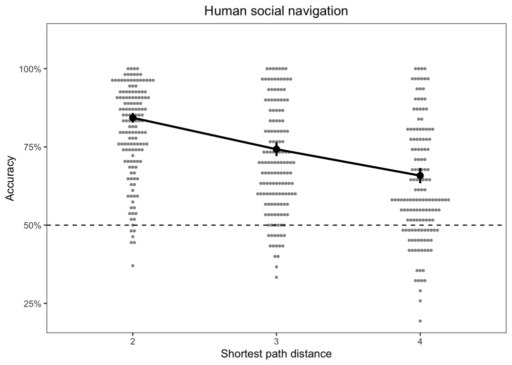

```r
predict_nav_day1 <- expand_grid(
  measurement_id = "D1",
  shortest_path = factor(2:4),
  sub_id = NA, study = NA
) %>%
  predict_glmmTMB(stats_nav_day1_dist2)

plot_nav_day1 <- nav_day1 %>%
  group_by(sub_id, shortest_path) %>%
  summarise(accuracy = mean(correct), .groups = "drop") %>%
  ggplot(aes(x=shortest_path, y=accuracy)) +
  theme_custom() +
  geom_hline(yintercept = 0.5, linetype = "dashed") +
  geom_dotplot(
    binwidth = 0.01,
    binaxis = "y", stackdir = "center",
    position = position_dodge(width = 0.75),
    dotsize = 1, alpha = 0.5, color = NA,
    show.legend = FALSE
  ) +
  geom_pointrange(
    aes(x = shortest_path, y = fit, ymin = fit - se.fit, ymax = fit + se.fit),
    data = predict_nav_day1, inherit.aes = FALSE, show.legend = FALSE,
    position = position_dodge(width = 0.15), linewidth = 1
  ) +
  geom_line(
    aes(x = shortest_path, y = fit, group = measurement_id),
    data = predict_nav_day1, inherit.aes = FALSE,
    position = position_dodge(width = 0.15), linewidth = 1
  ) +
  scale_x_discrete(name = "Shortest path distance") +
  scale_y_continuous(
    name = "Accuracy", labels = scales::percent, breaks = seq(0, 1, 0.25)
  ) +
  coord_cartesian(ylim = c(0.2, 1.1)) +
  theme(legend.position = "bottom") +
  ggtitle("Human social navigation")

plot_nav_day1
```

```r
if (knitting) {
  ggsave(
    here("outputs", workflow_name, str_c("navigation_before_rest", ".pdf")),
    plot = plot_nav_day1,
    width = 6, height = 4,
    units = "in", dpi = 300
  )
}
```

# After rest: Does navigation improve?

First, some descriptives…

```r
bind_rows(nav_study2, nav_study3) %>%
  filter(measurement_id %in% c("D1", "D2")) %>%
  group_by(measurement_id, shortest_path) %>%
  summarise(accuracy = mean(correct), .groups = "drop") %>%
  arrange(measurement_id, shortest_path) %>%
  pivot_wider(
    names_from = shortest_path, values_from = accuracy, names_prefix = "dist-"
  ) %>%
  kable_custom("Descriptive: Navigation accuracy", digits = 2)
```

Descriptive: Navigation accuracy

| measurement_id | dist-2 | dist-3 | dist-4 |
| --- | --- | --- | --- |
| D1 | 0.81 | 0.73 | 0.65 |
| D2 | 0.82 | 0.75 | 0.71 |

```r
nav_study3 %>%
  group_by(measurement_id, shortest_path) %>%
  summarise(accuracy = mean(correct), .groups = "drop") %>%
  arrange(measurement_id, shortest_path) %>%
  pivot_wider(
    names_from = shortest_path, values_from = accuracy, names_prefix = "dist-"
  ) %>%
  kable_custom(
    c("Descriptive: Navigation accuracy", "(Study 3 only)"), digits = 2
  )
```

Descriptive: Navigation accuracy (Study 3 only)

| measurement_id | dist-2 | dist-3 | dist-4 |
| --- | --- | --- | --- |
| D1 | 0.81 | 0.74 | 0.66 |
| D1b | 0.79 | 0.72 | 0.68 |
| D2 | 0.82 | 0.74 | 0.71 |

## Overnight rest

In the mixed-effects logistic regression, we’re pooling across studies 2-3 (study 1 was only a one-day experiment).

```r
nav_day1_to_day2 <- bind_rows(nav_study2, nav_study3) %>%
  filter(measurement_id %in% c("D1", "D2")) %>%
  # Give every subject a distinct identifier
  mutate(sub_id = str_c(study, " s", sub_id))

stats_nav_day2_dist2 <- nav_day1_to_day2 %>%
  mutate(shortest_path = fct_relevel(shortest_path, "2")) %>%
  glmmTMB(
    correct ~ shortest_path * measurement_id +
      (1 + shortest_path + measurement_id | sub_id) + (1 | study),
    family = binomial,
    data = .
  )

stats_nav_day2_dist3 <- nav_day1_to_day2 %>%
  mutate(shortest_path = fct_relevel(shortest_path, "3")) %>%
  glmmTMB(
    correct ~ shortest_path * measurement_id +
      (1 + shortest_path + measurement_id | sub_id) + (1 | study),
    family = binomial,
    data = .
  )

stats_nav_day2_dist4 <- nav_day1_to_day2 %>%
  mutate(shortest_path = fct_relevel(shortest_path, "4")) %>%
  glmmTMB(
    correct ~ shortest_path * measurement_id +
      (1 + shortest_path + measurement_id | sub_id) + (1 | study),
    family = binomial,
    data = .
  )

map_dfr(
  .x = list(
    "dist-2" = stats_nav_day2_dist2,
    "dist-3" = stats_nav_day2_dist3,
    "dist-4" = stats_nav_day2_dist4
  ),
  .f = ~tidy(.x, conf.int = TRUE),
  .id = "ref_cat"
) %>%
  check_significance() %>%
  select(-c(effect, component)) %>%
  kable_custom(
    "Navigation accuracy: Day 1 to Day 2",
    grouping_var = ref_cat, digits = 3
  )
```

Navigation accuracy: Day 1 to Day 2

group

term

estimate

std.error

statistic

p.value

conf.low

conf.high

sig

**dist-2**

NA

(Intercept)

1.765

0.114

15.476

0.000

1.541

1.988

***

NA

shortest_path3

-0.452

0.083

-5.452

0.000

-0.615

-0.290

***

NA

shortest_path4

-0.959

0.091

-10.554

0.000

-1.137

-0.781

***

NA

measurement_idD2

0.234

0.080

2.906

0.004

0.076

0.391

NA

shortest_path3:measurement_idD2

0.030

0.087

0.351

0.725

-0.139

0.200

NA

shortest_path4:measurement_idD2

0.196

0.083

2.356

0.018

0.033

0.359

sub_id

sd__(Intercept)

1.024

NA

NA

NA

0.858

1.223

sub_id

sd__shortest_path3

0.461

NA

NA

NA

0.334

0.635

sub_id

sd__shortest_path4

0.634

NA

NA

NA

0.512

0.785

sub_id

sd__measurement_idD2

0.483

NA

NA

NA

0.370

0.631

sub_id

cor__(Intercept).shortest_path3

0.182

NA

NA

NA

-0.175

0.481

sub_id

cor__(Intercept).shortest_path4

-0.250

NA

NA

NA

-0.799

0.057

sub_id

cor__(Intercept).measurement_idD2

0.451

NA

NA

NA

-0.037

0.608

sub_id

cor__shortest_path3.shortest_path4

0.808

NA

NA

NA

0.311

0.873

sub_id

cor__shortest_path3.measurement_idD2

0.466

NA

NA

NA

-0.116

0.837

sub_id

cor__shortest_path4.measurement_idD2

0.007

NA

NA

NA

-0.520

0.712

study

sd__(Intercept)

0.000

NA

NA

NA

0.000

Inf

**dist-3**

NA

(Intercept)

1.312

0.134

9.810

0.000

1.050

1.574

***

NA

shortest_path2

0.452

0.083

5.452

0.000

0.290

0.615

***

NA

shortest_path4

-0.507

0.079

-6.411

0.000

-0.662

-0.352

***

NA

measurement_idD2

0.264

0.088

2.989

0.003

0.091

0.437

NA

shortest_path2:measurement_idD2

-0.030

0.087

-0.351

0.725

-0.200

0.139

NA

shortest_path4:measurement_idD2

0.166

0.090

1.833

0.067

-0.011

0.343

.

sub_id

sd__(Intercept)

1.197

NA

NA

NA

0.997

1.437

sub_id

sd__shortest_path2

0.461

NA

NA

NA

0.334

0.635

sub_id

sd__shortest_path4

0.377

NA

NA

NA

0.266

0.536

sub_id

sd__measurement_idD2

0.483

NA

NA

NA

0.370

0.631

sub_id

cor__(Intercept).shortest_path2

-0.541

NA

NA

NA

-0.743

-0.174

sub_id

cor__(Intercept).shortest_path4

-0.497

NA

NA

NA

-0.605

0.049

sub_id

cor__(Intercept).measurement_idD2

0.565

NA

NA

NA

-0.045

0.827

sub_id

cor__shortest_path2.shortest_path4

-0.137

NA

NA

NA

-0.002

0.234

sub_id

cor__shortest_path2.measurement_idD2

-0.466

NA

NA

NA

-0.209

0.025

sub_id

cor__shortest_path4.measurement_idD2

-0.557

NA

NA

NA

-0.093

0.401

study

sd__(Intercept)

0.000

NA

NA

NA

0.000

Inf

**dist-4**

NA

(Intercept)

0.805

0.118

6.827

0.000

0.574

1.037

***

NA

shortest_path2

0.959

0.091

10.554

0.000

0.781

1.137

***

NA

shortest_path3

0.507

0.079

6.411

0.000

0.352

0.662

***

NA

measurement_idD2

0.430

0.083

5.174

0.000

0.267

0.592

***

NA

shortest_path2:measurement_idD2

-0.196

0.083

-2.356

0.018

-0.359

-0.033

NA

shortest_path3:measurement_idD2

-0.166

0.090

-1.834

0.067

-0.343

0.011

.

sub_id

sd__(Intercept)

1.061

NA

NA

NA

0.883

1.276

sub_id

sd__shortest_path2

0.634

NA

NA

NA

0.512

0.785

sub_id

sd__shortest_path3

0.377

NA

NA

NA

0.265

0.536

sub_id

sd__measurement_idD2

0.483

NA

NA

NA

0.370

0.631

sub_id

cor__(Intercept).shortest_path2

-0.356

NA

NA

NA

-0.587

-0.038

sub_id

cor__(Intercept).shortest_path3

0.205

NA

NA

NA

-0.465

0.400

sub_id

cor__(Intercept).measurement_idD2

0.439

NA

NA

NA

-0.096

0.450

sub_id

cor__shortest_path2.shortest_path3

0.695

NA

NA

NA

0.448

0.848

sub_id

cor__shortest_path2.measurement_idD2

-0.007

NA

NA

NA

-0.118

0.214

sub_id

cor__shortest_path3.measurement_idD2

0.557

NA

NA

NA

-0.497

0.628

study

sd__(Intercept)

0.000

NA

NA

NA

0.000

Inf

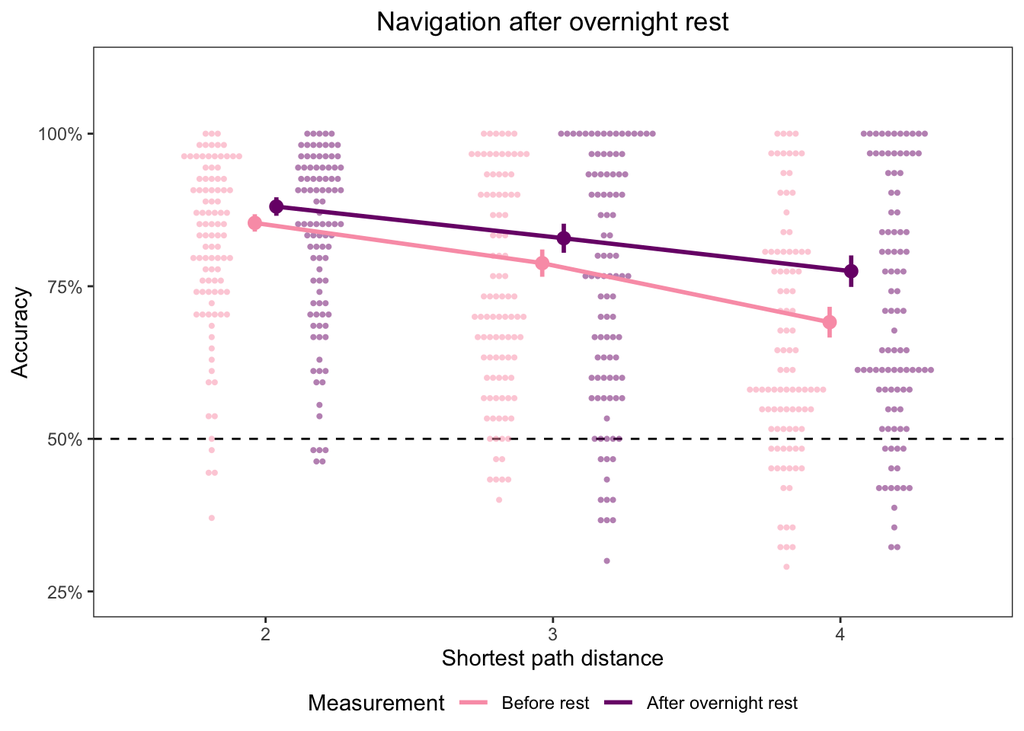

```r
predict_nav_day1_to_day2 <- expand_grid(
  measurement_id = c("D1", "D2"),
  shortest_path = factor(2:4),
  sub_id = NA, study = NA
) %>%
  predict_glmmTMB(stats_nav_day2_dist2)

plot_nav_day1_to_day2 <- nav_day1_to_day2 %>%
  group_by(sub_id, measurement_id, shortest_path) %>%
  summarise(accuracy = mean(correct), .groups = "drop") %>%
  ggplot(aes(x=shortest_path, y=accuracy, color=measurement_id)) +
  theme_custom() +
  geom_hline(yintercept = 0.5, linetype = "dashed") +
  geom_dotplot(
    aes(fill = measurement_id),
    binwidth = 0.01,
    binaxis = "y", stackdir = "center",
    position = position_dodge(width = 0.75),
    dotsize = 1, alpha = 0.5, color = NA,
    show.legend = FALSE
  ) +
  geom_pointrange(
    aes(
      x = shortest_path, y = fit,
      ymin = fit - se.fit, ymax = fit + se.fit,
      color = measurement_id
    ),
    data = predict_nav_day1_to_day2, inherit.aes = FALSE, show.legend = FALSE,
    position = position_dodge(width = 0.15), linewidth = 1
  ) +
  geom_line(
    aes(
      x = shortest_path, y = fit,
      group = measurement_id, color = measurement_id
    ),
    data = predict_nav_day1_to_day2, inherit.aes = FALSE,
    position = position_dodge(width = 0.15), linewidth = 1
  ) +
  scale_x_discrete(name = "Shortest path distance") +
  scale_y_continuous(
    name = "Accuracy", labels = scales::percent, breaks = seq(0, 1, 0.25)
  ) +
  scale_color_manual(
    name = "Measurement",
    values = c("D1"="#fa9fb5", "D2"="#7a0177"),
    labels = c("D1"="Before rest", "D2"="After overnight rest")
  ) +
  scale_fill_manual(values = c("D1"="#fa9fb5", "D2"="#7a0177")) +
  coord_cartesian(ylim = c(0.25, 1.1)) +
  theme(legend.position = "bottom") +
  ggtitle("Navigation after overnight rest")

plot_nav_day1_to_day2
```

```r
if (knitting) {
  ggsave(
    here("outputs", workflow_name, str_c("navigation_overnight_rest", ".pdf")),
    plot = plot_nav_day1_to_day2,
    width = 6, height = 4,
    units = "in", dpi = 300
  )
}
```

## Awake rest

Is a brief period of awake rest sufficient for improving navigation accuracy?

```r
stats_nav_awake_dist2 <- nav_study3 %>%
  filter(measurement_id %in% c("D1", "D1b")) %>%
  mutate(shortest_path = fct_relevel(shortest_path, "2")) %>%
  glmmTMB(
    correct ~ shortest_path * measurement_id +
      (1 + shortest_path + measurement_id | sub_id),
    family = binomial,
    data = .
  )

stats_nav_awake_dist3 <- nav_study3 %>%
  filter(measurement_id %in% c("D1", "D1b")) %>%
  mutate(shortest_path = fct_relevel(shortest_path, "3")) %>%
  glmmTMB(
    correct ~ shortest_path * measurement_id +
      (1 + shortest_path + measurement_id | sub_id),
    family = binomial,
    data = .
  )

stats_nav_awake_dist4 <- nav_study3 %>%
  filter(measurement_id %in% c("D1", "D1b")) %>%
  mutate(shortest_path = fct_relevel(shortest_path, "4")) %>%
  glmmTMB(
    correct ~ shortest_path * measurement_id +
      (1 + shortest_path + measurement_id | sub_id),
    family = binomial,
    data = .
  )

map_dfr(
  .x = list(
    "dist-2" = stats_nav_awake_dist2,
    "dist-3" = stats_nav_awake_dist3,
    "dist-4" = stats_nav_awake_dist4
  ),
  .f = ~tidy(.x, conf.int = TRUE),
  .id = "ref_cat"
) %>%
  check_significance() %>%
  select(-c(effect, component)) %>%
  kable_custom(
    "Navigation accuracy: Awake Rest",
    grouping_var = ref_cat, digits = 3
  )
```

Navigation accuracy: Awake Rest

group

term

estimate

std.error

statistic

p.value

conf.low

conf.high

sig

**dist-2**

NA

(Intercept)

1.840

0.193

9.542

0.000

1.462

2.218

***

NA

shortest_path3

-0.424

0.129

-3.290

0.001

-0.677

-0.171

NA

shortest_path4

-0.936

0.134

-6.972

0.000

-1.199

-0.673

***

NA

measurement_idD1b

-0.058

0.122

-0.475

0.635

-0.296

0.181

NA

shortest_path3:measurement_idD1b

0.022

0.123

0.175

0.861

-0.220

0.263

NA

shortest_path4:measurement_idD1b

0.244

0.119

2.060

0.039

0.012

0.477

sub_id

sd__(Intercept)

1.216

NA

NA

NA

0.947

1.561

sub_id

sd__shortest_path3

0.518

NA

NA

NA

0.352

0.764

sub_id

sd__shortest_path4

0.632

NA

NA

NA

0.465

0.859

sub_id

sd__measurement_idD1b

0.544

NA

NA

NA

0.395

0.751

sub_id

cor__(Intercept).shortest_path3

-0.019

NA

NA

NA

-0.462

0.435

sub_id

cor__(Intercept).shortest_path4

-0.262

NA

NA

NA

-0.840

0.127

sub_id

cor__(Intercept).measurement_idD1b

0.045

NA

NA

NA

-0.264

0.378

sub_id

cor__shortest_path3.shortest_path4

0.845

NA

NA

NA

0.444

0.913

sub_id

cor__shortest_path3.measurement_idD1b

0.191

NA

NA

NA

-0.062

0.647

sub_id

cor__shortest_path4.measurement_idD1b

-0.024

NA

NA

NA

-0.184

0.641

**dist-3**

NA

(Intercept)

1.416

0.211

6.714

0.000

1.003

1.829

***

NA

shortest_path2

0.424

0.129

3.290

0.001

0.171

0.677

NA

shortest_path4

-0.512

0.116

-4.427

0.000

-0.738

-0.285

***

NA

measurement_idD1b

-0.036

0.133

-0.273

0.785

-0.296

0.224

NA

shortest_path2:measurement_idD1b

-0.022

0.123

-0.175

0.861

-0.263

0.220

NA

shortest_path4:measurement_idD1b

0.223

0.129

1.722

0.085

-0.031

0.476

.

sub_id

sd__(Intercept)

1.313

NA

NA

NA

1.010

1.705

sub_id

sd__shortest_path2

0.518

NA

NA

NA

0.352

0.764

sub_id

sd__shortest_path4

0.338

NA

NA

NA

0.190

0.603

sub_id

sd__measurement_idD1b

0.544

NA

NA

NA

0.395

0.751

sub_id

cor__(Intercept).shortest_path2

-0.377

NA

NA

NA

-0.704

0.175

sub_id

cor__(Intercept).shortest_path4

-0.408

NA

NA

NA

-0.681

0.342

sub_id

cor__(Intercept).measurement_idD1b

0.117

NA

NA

NA

-0.224

0.497

sub_id

cor__shortest_path2.shortest_path4

-0.046

NA

NA

NA

0.106

0.502

sub_id

cor__shortest_path2.measurement_idD1b

-0.191

NA

NA

NA

-0.124

0.355

sub_id

cor__shortest_path4.measurement_idD1b

-0.337

NA

NA

NA

0.009

0.560

**dist-4**

NA

(Intercept)

0.904

0.193

4.684

0.000

0.526

1.283

***

NA

shortest_path2

0.936

0.134

6.971

0.000

0.673

1.199

***

NA

shortest_path3

0.512

0.116

4.427

0.000

0.285

0.738

***

NA

measurement_idD1b

0.187

0.126

1.476

0.140

-0.061

0.434

NA

shortest_path2:measurement_idD1b

-0.244

0.119

-2.060

0.039

-0.477

-0.012

NA

shortest_path3:measurement_idD1b

-0.223

0.129

-1.722

0.085

-0.476

0.031

.

sub_id

sd__(Intercept)

1.214

NA

NA

NA

0.935

1.577

sub_id

sd__shortest_path2

0.632

NA

NA

NA

0.465

0.859

sub_id

sd__shortest_path3

0.338

NA

NA

NA

0.190

0.603

sub_id

sd__measurement_idD1b

0.544

NA

NA

NA

0.395

0.751

sub_id

cor__(Intercept).shortest_path2

-0.258

NA

NA

NA

-0.602

0.216

sub_id

cor__(Intercept).shortest_path3

0.163

NA

NA

NA

-0.621

0.521

sub_id

cor__(Intercept).measurement_idD1b

0.033

NA

NA

NA

-0.386

0.307

sub_id

cor__shortest_path2.shortest_path3

0.573

NA

NA

NA

0.343

0.835

sub_id

cor__shortest_path2.measurement_idD1b

0.024

NA

NA

NA

-0.041

0.338

sub_id

cor__shortest_path3.measurement_idD1b

0.337

NA

NA

NA

-0.003

0.674

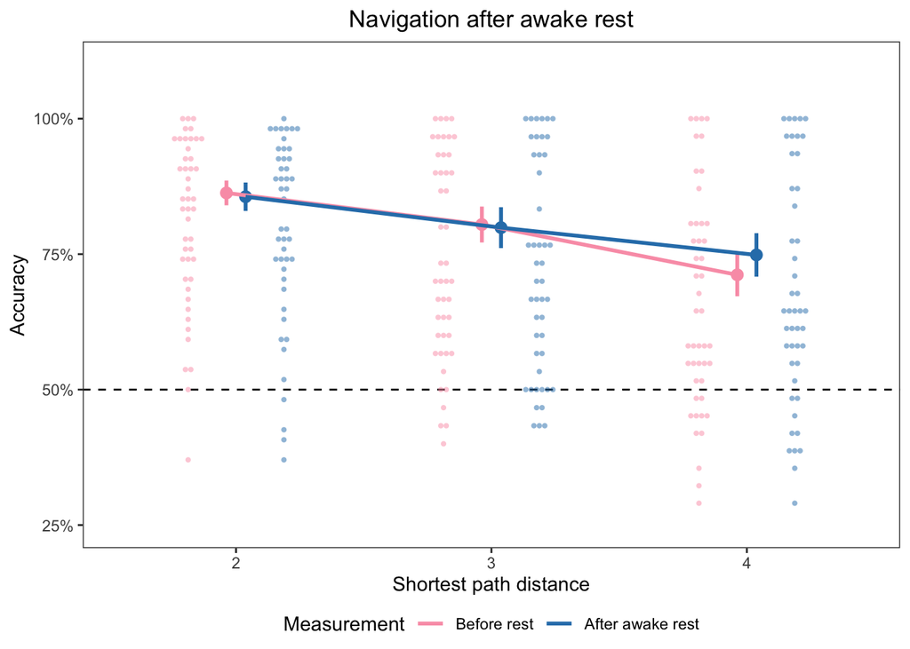

```r
predict_nav_awake <- expand_grid(
  measurement_id = c("D1", "D1b"),
  shortest_path = factor(2:4),
  sub_id = NA, study = NA
) %>%
  predict_glmmTMB(stats_nav_awake_dist2)

plot_nav_awake <- nav_study3 %>%
  filter(measurement_id %in% c("D1", "D1b")) %>%
  group_by(sub_id, measurement_id, shortest_path) %>%
  summarise(accuracy = mean(correct), .groups = "drop") %>%
  ggplot(aes(x=shortest_path, y=accuracy, color=measurement_id)) +
  theme_custom() +
  geom_hline(yintercept = 0.5, linetype = "dashed") +
  geom_dotplot(
    aes(fill = measurement_id),
    binwidth = 0.01,
    binaxis = "y", stackdir = "center",
    position = position_dodge(width = 0.75),
    dotsize = 1, alpha = 0.5, color = NA,
    show.legend = FALSE
  ) +
  geom_pointrange(
    aes(
      x = shortest_path, y = fit,
      ymin = fit - se.fit, ymax = fit + se.fit,
      color = measurement_id
    ),
    data = predict_nav_awake, inherit.aes = FALSE, show.legend = FALSE,
    position = position_dodge(width = 0.15), linewidth = 1
  ) +
  geom_line(
    aes(
      x = shortest_path, y = fit,
      group = measurement_id, color = measurement_id
    ),
    data = predict_nav_awake, inherit.aes = FALSE,
    position = position_dodge(width = 0.15), linewidth = 1
  ) +
  scale_x_discrete(name = "Shortest path distance") +
  scale_y_continuous(
    name = "Accuracy", labels = scales::percent, breaks = seq(0, 1, 0.25)
  ) +
  scale_color_manual(
    name = "Measurement",
    values = c("D1"="#fa9fb5", "D1b"="#2c7fb8"),
    labels = c("D1"="Before rest", "D1b"="After awake rest")
  ) +
  scale_fill_manual(values = c("D1"="#fa9fb5", "D1b"="#2c7fb8")) +
  coord_cartesian(ylim = c(0.25, 1.1)) +
  theme(legend.position = "bottom") +
  ggtitle("Navigation after awake rest")

plot_nav_awake
```

```r
if (knitting) {
  ggsave(
    here("outputs", workflow_name, str_c("navigation_awake_rest", ".pdf")),
    plot = plot_nav_awake,
    width = 6, height = 4,
    units = "in", dpi = 300
  )
}
```

# Relating behavior to model parameters

Does estimated gamma significantly increase after overnight rest?

```r
changes_in_gamma <- params %>%
  filter(
    study %in% c("Study 2", "Study 3"),
    measurement_id %in% c("D1", "D2"),
    model == "sr_analytic",
    param_name == "sr_gamma"
  ) %>%
  select(study, sub_id, measurement_id, sr_gamma = param_value) %>%
  mutate(lookahead = 1/(1-sr_gamma)) %>%
  arrange(study, sub_id, measurement_id) %>%
  group_by(study, sub_id) %>%
  mutate(
    delta_gamma = sr_gamma - first(sr_gamma),
    delta_lookahead = lookahead - first(lookahead)
  ) %>%
  ungroup()

changes_in_behavior <- bind_rows(nav_study2, nav_study3) %>%
  filter(measurement_id %in% c("D1", "D2")) %>%
  group_by(study, sub_id, measurement_id, shortest_path) %>%
  summarise(accuracy = mean(correct), .groups = "drop") %>%
  arrange(study, sub_id, shortest_path, measurement_id) %>%
  group_by(study, sub_id, shortest_path) %>%
  mutate(delta_accuracy = accuracy - first(accuracy)) %>%
  ungroup()
```

```r
changes_in_gamma %>%
  group_by(measurement_id) %>%
  summarise(
    median_gamma = median(sr_gamma),
    median_lookahead = median(lookahead)
  ) %>%
  kable_custom("Median SR gamma before/after overnight rest", digits = 3)
```

Median SR gamma before/after overnight rest

| measurement_id | median_gamma | median_lookahead |
| --- | --- | --- |
| D1 | 0.752 | 4.025 |
| D2 | 0.831 | 5.932 |

```r
changes_in_gamma %>%
  select(study, sub_id, measurement_id, sr_gamma) %>%
  pivot_wider(names_from = measurement_id, values_from = sr_gamma) %>%
  with(
    wilcox.test(
      D2, D1, alternative = "greater", paired = TRUE, conf.int = TRUE
    )
  ) %>%
  tidy() %>%
  kable_custom("Increase in SR gamma after overnight rest", digits = 3)
```

Increase in SR gamma after overnight rest

| estimate | statistic | p.value | conf.low | conf.high | method | alternative |
| --- | --- | --- | --- | --- | --- | --- |
| 0.037 | 2899 | 0.019 | 0.009 | Inf | Wilcoxon signed rank test with continuity correction | greater |

```r
changes_in_gamma %>%
  select(study, sub_id, measurement_id, lookahead) %>%
  pivot_wider(names_from = measurement_id, values_from = lookahead) %>%
  with(
    wilcox.test(
      D2, D1, alternative = "greater", paired = TRUE, conf.int = TRUE
    )
  ) %>%
  tidy() %>%
  kable_custom("Increase in SR lookahead after overnight rest", digits = 3)
```

Increase in SR lookahead after overnight rest

| estimate | statistic | p.value | conf.low | conf.high | method | alternative |
| --- | --- | --- | --- | --- | --- | --- |
| 1.733 | 3197 | 0.001 | 0.706 | Inf | Wilcoxon signed rank test with continuity correction | greater |

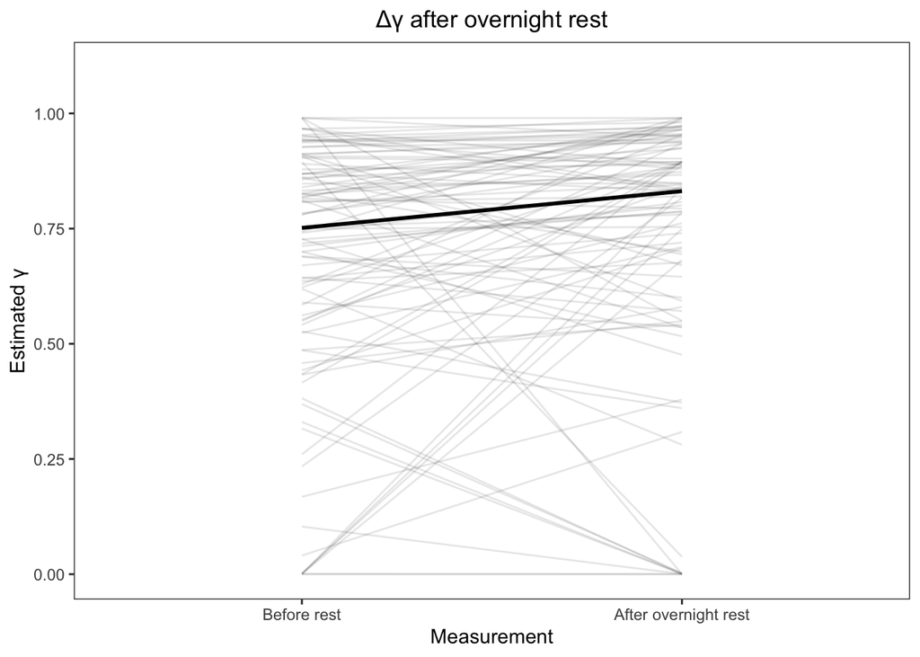

```r
plot_gamma_change <- changes_in_gamma %>%
  select(study, sub_id, measurement_id, sr_gamma) %>%
  ggplot(aes(x=measurement_id, y=sr_gamma)) +
  theme_custom() +
  geom_line(aes(group = interaction(study, sub_id)), alpha = 0.1) +
  stat_summary(
    aes(group = 1), geom = "line", fun = median, linewidth = 1
  ) +
  scale_x_discrete(
    name = "Measurement",
    labels = c("D1"="Before rest", "D2"="After overnight rest")
  ) +
  scale_y_continuous(
    name = str_c("Estimated ", unicode_greek["gamma"]),
    breaks = seq(0, 1, 0.25)
  ) +
  coord_cartesian(ylim = c(0, 1.1)) +
  theme(legend.position = "bottom") +
  ggtitle(
    str_c(
      unicode_greek["Delta"], unicode_greek["gamma"], " after overnight rest"
    )
  )

plot_gamma_change
```

```r
if (knitting) {
  ggsave(
    here("outputs", workflow_name, str_c("gamma_change", ".pdf")),
    plot = plot_gamma_change,
    width = 6, height = 4,
    units = "in", dpi = 300,
    device = cairo_pdf
  )
}
```

Are changes in estimated gamma related to changes in navigation behaviors?

```r
changes_in_behavior %>%
  filter(measurement_id == "D2") %>%
  left_join(
    changes_in_gamma %>%
      filter(measurement_id == "D2"),
    by = join_by(study, sub_id, measurement_id)
  ) %>%
  group_by(shortest_path) %>%
  nest() %>%
  mutate(
    test = map(
      .x = data,
      .f = ~with(
        .x,
        cor.test(
          delta_accuracy, delta_gamma,
          method = "spearman", exact = FALSE, alternative = "greater"
        )
      ) %>% tidy()
    )
  ) %>%
  unnest(test) %>%
  ungroup() %>%
  select(-data) %>%
  kable_custom("∆ Accuracy ~ ∆ SR gamma (after overnight rest)", digits = 3)
```

∆ Accuracy ~ ∆ SR gamma (after overnight rest)

| shortest_path | estimate | statistic | p.value | method | alternative |
| --- | --- | --- | --- | --- | --- |
| 2 | -0.229 | 181149.93 | 0.987 | Spearman’s rank correlation rho | greater |
| 3 | 0.547 | 66795.66 | 0.000 | Spearman’s rank correlation rho | greater |
| 4 | 0.473 | 77654.21 | 0.000 | Spearman’s rank correlation rho | greater |

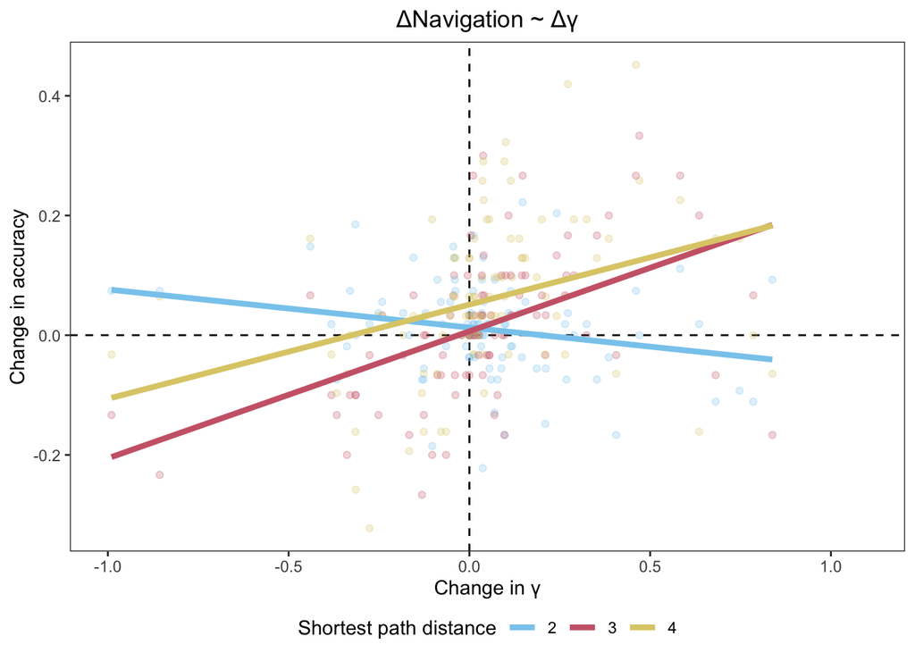

```r
plot_gamma_accuracy_change <- changes_in_behavior %>%
  filter(measurement_id == "D2") %>%
  left_join(
    changes_in_gamma %>%
      filter(measurement_id == "D2"),
    by = join_by(study, sub_id, measurement_id)
  ) %>%
  ggplot(aes(x=delta_gamma, y=delta_accuracy, color=shortest_path)) +
  theme_custom() +
  geom_hline(yintercept = 0, linetype = "dashed") +
  geom_vline(xintercept = 0, linetype = "dashed") +
  geom_point(alpha = 0.25, show.legend = FALSE) +
  geom_smooth(method = "lm", se = FALSE, linewidth = 1.5) +
  scale_x_continuous(name = str_c("Change in ", unicode_greek["gamma"])) +
  scale_y_continuous(name = "Change in accuracy") +
  scale_color_manual(
    name = "Shortest path distance",
    values = c("#88CCEE", "#CC6677", "#DDCC77")
  ) +
  coord_cartesian(xlim = c(-1, 1.1)) +
  theme(legend.position = "bottom") +
  ggtitle(
    str_c(
      unicode_greek["Delta"], "Navigation ~ ",
      unicode_greek["Delta"], unicode_greek["gamma"]
    )
  )

plot_gamma_accuracy_change
```

```r
if (knitting) {
  ggsave(
    here("outputs", workflow_name, str_c("gamma_accuracy_change", ".pdf")),
    plot = plot_gamma_accuracy_change,
    width = 6, height = 4,
    units = "in", dpi = 300,
    device = cairo_pdf
  )
}
```

# Do people bring social priors into learning?

In principle, it’s possible that subjects would have shown comparable “navigation” behaviors if they’d learned about a network of (e.g.) computers transmitting messages to each other. It’d be nice if we could find some evidence that subjects construed the task as being “social”, so we’ll see if there’s evidence that people bring social priors about homophily into learning.

```r
adjlist <- here("data", "clean_data", "adjlist_learned.csv") %>%
  read_csv(show_col_types = FALSE)

nodes_study1 <- here("data", "clean_data", "study1_node_mappings.csv") %>%
  read_csv(show_col_types = FALSE)

nodes_study2 <- here("data", "clean_data", "study2_node_mappings.csv") %>%
  read_csv(show_col_types = FALSE)

nodes_study3 <- here("data", "clean_data", "study3_node_mappings.csv") %>%
  read_csv(show_col_types = FALSE)

learn_study1 <- here("data", "clean_data", "study1_learn.csv") %>%
  read_csv(show_col_types = FALSE) %>%
  mutate(
    block = case_when(
      trial <= 13 ~ 1,
      trial <= 13*2 ~ 2,
      trial <= 13*3 ~ 3,
      trial <= 13*4 ~ 4,
      trial <= 13*5 ~ 5,
      trial <= 13*6 ~ 6
    )
  ) %>%
  select(sub_id, block, from = target_id, to = guess_id, guess_correct)

learn_study2 <- here("data", "clean_data", "study2_learn.csv") %>%
  read_csv(show_col_types = FALSE) %>%
  mutate(
    block = case_when(
      trial <= 13 ~ 1,
      trial <= 13*2 ~ 2,
      trial <= 13*3 ~ 3,
      trial <= 13*4 ~ 4,
      trial <= 13*5 ~ 5,
      trial <= 13*6 ~ 6
    )
  ) %>%
  select(sub_id, block, from = target_id, to = guess_id, guess_correct)

learn_study3 <- here("data", "clean_data", "study3_learn.csv") %>%
  read_csv(show_col_types = FALSE) %>%
  mutate(
    block = case_when(
      trial <= 13 ~ 1,
      trial <= 13*2 ~ 2,
      trial <= 13*3 ~ 3,
      trial <= 13*4 ~ 4,
      trial <= 13*5 ~ 5,
      trial <= 13*6 ~ 6
    )
  ) %>%
  select(sub_id, block, from = target_id, to = guess_id, guess_correct)
```

```r
learn_study1_nodes <- expand_grid(
  sub_id = sort(unique(learn_study1$sub_id)),
  block = 1:6,
  from = 1:13,
  to = from
) %>%
  filter(from != to) %>%
  left_join(learn_study1) %>%
  mutate(guessed_friends = !is.na(guess_correct)) %>%
  select(-guess_correct) %>%
  left_join(adjlist, by = join_by(from, to)) %>%
  left_join(
    nodes_study1 %>%
      select(
        sub_id,
        from = node_id,
        from_race = node_race,
        from_gender = node_gender
      ),
    by = join_by(sub_id, from)
  ) %>%
  left_join(
    nodes_study1 %>%
      select(
        sub_id,
        to = node_id,
        to_race = node_race,
        to_gender = node_gender
      ),
    by = join_by(sub_id, to)
  )
learn_study2_nodes <- expand_grid(
  sub_id = sort(unique(learn_study2$sub_id)),
  block = 1:6,
  from = 1:13,
  to = from
) %>%
  filter(from != to) %>%
  left_join(learn_study2) %>%
  mutate(guessed_friends = !is.na(guess_correct)) %>%
  select(-guess_correct) %>%
  left_join(adjlist, by = join_by(from, to)) %>%
  left_join(
    nodes_study2 %>%
      select(
        sub_id,
        from = node_id,
        from_race = node_race,
        from_gender = node_gender
      ),
    by = join_by(sub_id, from)
  ) %>%
  left_join(
    nodes_study2 %>%
      select(
        sub_id,
        to = node_id,
        to_race = node_race,
        to_gender = node_gender
      ),
    by = join_by(sub_id, to)
  )
learn_study3_nodes <- expand_grid(
  sub_id = sort(unique(learn_study3$sub_id)),
  block = 1:6,
  from = 1:13,
  to = from
) %>%
  filter(from != to) %>%
  left_join(learn_study3) %>%
  mutate(guessed_friends = !is.na(guess_correct)) %>%
  select(-guess_correct) %>%
  left_join(adjlist, by = join_by(from, to)) %>%
  left_join(
    nodes_study3 %>%
      select(
        sub_id,
        from = node_id,
        from_race = node_race,
        from_gender = node_gender
      ),
    by = join_by(sub_id, from)
  ) %>%
  left_join(
    nodes_study3 %>%
      select(
        sub_id,
        to = node_id,
        to_race = node_race,
        to_gender = node_gender
      ),
    by = join_by(sub_id, to)
  )
```

In the mixed-effects logistic regression below, we’re trying to predict whether a subject guessed that two network members were friends, given that those network members were same-race or same-gender. To make sure that these actually reflect subjects’ priors, we’ll only look at responses where the two network members were *not* actually friends.

The learning task consisted of six blocks in total, where each block presented every network member as a Target. On each trial, subjects were presented with virtual flash cards. When shown a Target network member, participants were required to find all of the Target’s friends from the face-down cards. When a card corresponding to the Target’s friend was selected, the card flipped face-up to reveal their photograph. Cards remained face-down in response to incorrect guesses. To ensure that subjects were truly learning about friendships, rather than something low-level like the cards’ spatial location, we shuffled where the cards were located in block four. Due to this task design, subjects were only able to guess randomly during blocks one and four, and we therefore excluded these blocks from our analysis.

```r
bind_rows(
  learn_study1_nodes %>% mutate(study = 1),
  learn_study2_nodes %>% mutate(study = 2),
  learn_study3_nodes %>% mutate(study = 3),
) %>%
  # Homophily
  mutate(
    same_race = from_race == to_race,
    same_gender = from_gender == to_gender
  ) %>%
  # Only include blocks where the subject plausibly knew which face-down
  # flash cards were associated with which network member
  filter(block %in% c(2, 3, 5, 6)) %>%
  # Only look at pairs of network members who were NOT actually friends
  filter(edge == 0) %>%
  # Unique identifier for each subject, across studies
  mutate(sub_id = str_c("study", study, ", sub", sub_id)) %>%
  glmmTMB(
    guessed_friends ~ same_race + same_gender + (1 | sub_id) + (1 | study),
    family = binomial,
    data = .
  ) %>%
  tidy(conf.int = TRUE) %>%
  check_significance() %>%
  kable_custom("Learning task: Evidence of social priors", digits = 3)
```

Learning task: Evidence of social priors

| effect | component | group | term | estimate | std.error | statistic | p.value | conf.low | conf.high | sig |
| --- | --- | --- | --- | --- | --- | --- | --- | --- | --- | --- |
| fixed | cond | NA | (Intercept) | -0.953 | 0.100 | -9.523 | 0 | -1.149 | -0.757 | *** |
| fixed | cond | NA | same_raceTRUE | 0.167 | 0.021 | 8.007 | 0 | 0.126 | 0.208 | *** |
| fixed | cond | NA | same_genderTRUE | 0.169 | 0.017 | 9.800 | 0 | 0.135 | 0.202 | *** |
| ran_pars | cond | sub_id | sd__(Intercept) | 0.853 | NA | NA | NA | 0.756 | 0.963 |  |
| ran_pars | cond | study | sd__(Intercept) | 0.120 | NA | NA | NA | 0.023 | 0.618 |  |

To see how “sticky” these priors were, we can try looking *only* at the data from the last block. Even here, we see evidence that race and gender homophily influence subjects’ learning.

```r
bind_rows(
  learn_study1_nodes %>% mutate(study = 1),
  learn_study2_nodes %>% mutate(study = 2),
  learn_study3_nodes %>% mutate(study = 3),
) %>%
  # Homophily
  mutate(
    same_race = from_race == to_race,
    same_gender = from_gender == to_gender
  ) %>%
  # Only include the last block
  filter(block == 6) %>%
  # Only look at pairs of network members who were NOT actually friends
  filter(edge == 0) %>%
  # Unique identifier for each subject, across studies
  mutate(sub_id = str_c("study", study, ", sub", sub_id)) %>%
  glmmTMB(
    guessed_friends ~ same_race + same_gender + (1 | sub_id) + (1 | study),
    family = binomial,
    data = .
  ) %>%
  tidy(conf.int = TRUE) %>%
  check_significance() %>%
  kable_custom(
    c("Learning task: Evidence of social priors", "(Only last block)"),
    digits = 3
  )
```

Learning task: Evidence of social priors  
(Only last block)

effect

component

group

term

estimate

std.error

statistic

p.value

conf.low

conf.high

sig

fixed

cond

NA

(Intercept)

-1.723

0.179

-9.602

0.000

-2.074

-1.371

***

fixed

cond

NA

same_raceTRUE

0.113

0.049

2.290

0.022

0.016

0.209

fixed

cond

NA

same_genderTRUE

0.153

0.041

3.774

0.000

0.073

0.232

***

ran_pars

cond

sub_id

sd__(Intercept)

1.445

NA

NA

NA

1.267

1.648

ran_pars

cond

study

sd__(Intercept)

0.222

NA

NA

NA

0.048

1.013

# Social navigation, disaggregated

## Navigation before overnight rest

We want to know whether navigation accuracy is different from chance at each distance, so we’ll iteratively reparameterize the model so that each distance is the reference category.

We’ll start with study 1. Note that estimating a random slope leads to model convergence problems in studies 2-3, so we’ll only be estimating a random intercept per subject.

```r
stats_nav_study1_dist2 <- nav_study1 %>%
  mutate(shortest_path = fct_relevel(shortest_path, "2")) %>%
  glmmTMB(
    correct ~ shortest_path + (1 | sub_id),
    family = binomial,
    data = .
  )

stats_nav_study1_dist3 <- nav_study1 %>%
  mutate(shortest_path = fct_relevel(shortest_path, "3")) %>%
  glmmTMB(
    correct ~ shortest_path + (1 | sub_id),
    family = binomial,
    data = .
  )

stats_nav_study1_dist4 <- nav_study1 %>%
  mutate(shortest_path = fct_relevel(shortest_path, "4")) %>%
  glmmTMB(
    correct ~ shortest_path + (1  | sub_id),
    family = binomial,
    data = .
  )

map_dfr(
  .x = list(
    "dist-2" = stats_nav_study1_dist2,
    "dist-3" = stats_nav_study1_dist3,
    "dist-4" = stats_nav_study1_dist4
  ),
  .f = ~tidy(.x, conf.int = TRUE),
  .id = "ref_cat"
) %>%
  check_significance() %>%
  select(-c(effect, component)) %>%
  kable_custom(
    "Navigation accuracy: Day 1, Study 1", grouping_var = ref_cat, digits = 3
  )
```

Navigation accuracy: Day 1, Study 1

| group | term | estimate | std.error | statistic | p.value | conf.low | conf.high | sig |
| --- | --- | --- | --- | --- | --- | --- | --- | --- |
| **dist-2** |  |  |  |  |  |  |  |  |
| NA | (Intercept) | 1.343 | 0.105 | 12.758 | 0 | 1.137 | 1.550 | *** |
| NA | shortest_path3 | -0.656 | 0.074 | -8.898 | 0 | -0.800 | -0.511 | *** |
| NA | shortest_path4 | -0.931 | 0.072 | -12.924 | 0 | -1.072 | -0.790 | *** |
| sub_id | sd__(Intercept) | 0.659 | NA | NA | NA | 0.523 | 0.830 |  |
| **dist-3** |  |  |  |  |  |  |  |  |
| NA | (Intercept) | 0.688 | 0.109 | 6.294 | 0 | 0.474 | 0.902 | *** |
| NA | shortest_path2 | 0.656 | 0.074 | 8.898 | 0 | 0.511 | 0.800 | *** |
| NA | shortest_path4 | -0.275 | 0.078 | -3.532 | 0 | -0.428 | -0.123 | *** |
| sub_id | sd__(Intercept) | 0.659 | NA | NA | NA | 0.523 | 0.830 |  |
| **dist-4** |  |  |  |  |  |  |  |  |
| NA | (Intercept) | 0.412 | 0.108 | 3.821 | 0 | 0.201 | 0.624 | *** |
| NA | shortest_path2 | 0.931 | 0.072 | 12.924 | 0 | 0.790 | 1.072 | *** |
| NA | shortest_path3 | 0.275 | 0.078 | 3.532 | 0 | 0.123 | 0.428 | *** |
| sub_id | sd__(Intercept) | 0.659 | NA | NA | NA | 0.523 | 0.830 |  |

Moving on to study 2:

```r
stats_nav_study2_day1_dist2 <- nav_study2 %>%
  filter(measurement_id == "D1") %>%
  mutate(shortest_path = fct_relevel(shortest_path, "2")) %>%
  glmmTMB(
    correct ~ shortest_path + (1 | sub_id),
    family = binomial,
    data = .
  )

stats_nav_study2_day1_dist3 <- nav_study2 %>%
  filter(measurement_id == "D1") %>%
  mutate(shortest_path = fct_relevel(shortest_path, "3")) %>%
  glmmTMB(
    correct ~ shortest_path + (1 | sub_id),
    family = binomial,
    data = .
  )

stats_nav_study2_day1_dist4 <- nav_study2 %>%
  filter(measurement_id == "D1") %>%
  mutate(shortest_path = fct_relevel(shortest_path, "4")) %>%
  glmmTMB(
    correct ~ shortest_path + (1 | sub_id),
    family = binomial,
    data = .
  )

map_dfr(
  .x = list(
    "dist-2" = stats_nav_study2_day1_dist2,
    "dist-3" = stats_nav_study2_day1_dist3,
    "dist-4" = stats_nav_study2_day1_dist4
  ),
  .f = ~tidy(.x, conf.int = TRUE),
  .id = "ref_cat"
) %>%
  check_significance() %>%
  select(-c(effect, component)) %>%
  kable_custom(
    "Navigation accuracy: Day 1, Study 2", grouping_var = ref_cat, digits = 3
  )
```

Navigation accuracy: Day 1, Study 2

| group | term | estimate | std.error | statistic | p.value | conf.low | conf.high | sig |
| --- | --- | --- | --- | --- | --- | --- | --- | --- |
| **dist-2** |  |  |  |  |  |  |  |  |
| NA | (Intercept) | 1.712 | 0.134 | 12.774 | 0 | 1.449 | 1.975 | *** |
| NA | shortest_path3 | -0.574 | 0.080 | -7.172 | 0 | -0.731 | -0.417 | *** |
| NA | shortest_path4 | -1.012 | 0.077 | -13.151 | 0 | -1.162 | -0.861 | *** |
| sub_id | sd__(Intercept) | 0.861 | NA | NA | NA | 0.686 | 1.082 |  |
| **dist-3** |  |  |  |  |  |  |  |  |
| NA | (Intercept) | 1.138 | 0.137 | 8.281 | 0 | 0.868 | 1.407 | *** |
| NA | shortest_path2 | 0.574 | 0.080 | 7.172 | 0 | 0.417 | 0.731 | *** |
| NA | shortest_path4 | -0.437 | 0.083 | -5.264 | 0 | -0.600 | -0.274 | *** |
| sub_id | sd__(Intercept) | 0.861 | NA | NA | NA | 0.686 | 1.082 |  |
| **dist-4** |  |  |  |  |  |  |  |  |
| NA | (Intercept) | 0.700 | 0.135 | 5.187 | 0 | 0.436 | 0.965 | *** |
| NA | shortest_path2 | 1.012 | 0.077 | 13.151 | 0 | 0.861 | 1.162 | *** |
| NA | shortest_path3 | 0.437 | 0.083 | 5.264 | 0 | 0.274 | 0.600 | *** |
| sub_id | sd__(Intercept) | 0.861 | NA | NA | NA | 0.686 | 1.082 |  |

And finally study 3:

```r
stats_nav_study3_day1_dist2 <- nav_study3 %>%
  filter(measurement_id == "D1") %>%
  mutate(shortest_path = fct_relevel(shortest_path, "2")) %>%
  glmmTMB(
    correct ~ shortest_path + (1 | sub_id),
    family = binomial,
    data = .
  )

stats_nav_study3_day1_dist3 <- nav_study3 %>%
  filter(measurement_id == "D1") %>%
  mutate(shortest_path = fct_relevel(shortest_path, "3")) %>%
  glmmTMB(
    correct ~ shortest_path + (1 | sub_id),
    family = binomial,
    data = .
  )

stats_nav_study3_day1_dist4 <- nav_study3 %>%
  filter(measurement_id == "D1") %>%
  mutate(shortest_path = fct_relevel(shortest_path, "4")) %>%
  glmmTMB(
    correct ~ shortest_path + (1 | sub_id),
    family = binomial,
    data = .
  )

map_dfr(
  .x = list(
    "dist-2" = stats_nav_study3_day1_dist2,
    "dist-3" = stats_nav_study3_day1_dist3,
    "dist-4" = stats_nav_study3_day1_dist4
  ),
  .f = ~tidy(.x, conf.int = TRUE),
  .id = "ref_cat"
) %>%
  check_significance() %>%
  select(-c(effect, component)) %>%
  kable_custom(
    "Navigation accuracy: Day 1, Study 3", grouping_var = ref_cat, digits = 3
  )
```

Navigation accuracy: Day 1, Study 3

| group | term | estimate | std.error | statistic | p.value | conf.low | conf.high | sig |
| --- | --- | --- | --- | --- | --- | --- | --- | --- |
| **dist-2** |  |  |  |  |  |  |  |  |
| NA | (Intercept) | 1.813 | 0.186 | 9.757 | 0 | 1.449 | 2.178 | *** |
| NA | shortest_path3 | -0.459 | 0.085 | -5.365 | 0 | -0.626 | -0.291 | *** |
| NA | shortest_path4 | -0.921 | 0.082 | -11.213 | 0 | -1.082 | -0.760 | *** |
| sub_id | sd__(Intercept) | 1.182 | NA | NA | NA | 0.929 | 1.504 |  |
| **dist-3** |  |  |  |  |  |  |  |  |
| NA | (Intercept) | 1.355 | 0.189 | 7.160 | 0 | 0.984 | 1.726 | *** |
| NA | shortest_path2 | 0.459 | 0.085 | 5.365 | 0 | 0.291 | 0.626 | *** |
| NA | shortest_path4 | -0.463 | 0.090 | -5.129 | 0 | -0.639 | -0.286 | *** |
| sub_id | sd__(Intercept) | 1.182 | NA | NA | NA | 0.929 | 1.504 |  |
| **dist-4** |  |  |  |  |  |  |  |  |
| NA | (Intercept) | 0.892 | 0.187 | 4.770 | 0 | 0.526 | 1.259 | *** |
| NA | shortest_path2 | 0.921 | 0.082 | 11.213 | 0 | 0.760 | 1.082 | *** |
| NA | shortest_path3 | 0.463 | 0.090 | 5.129 | 0 | 0.286 | 0.639 | *** |
| sub_id | sd__(Intercept) | 1.182 | NA | NA | NA | 0.929 | 1.504 |  |

## Navigation after overnight rest

In studies 2-3, subjects returned to the lab after overnight rest. The primary analysis of interest is to test whether there is evidence of navigation accuracy increasing. Because we’re interested in addressing this question for each distance, we’ll be iteratively reparameterizing the models so that each distance is the reference category.

```r
stats_nav_study2_day2_dist2 <- nav_study2 %>%
  filter(measurement_id %in% c("D1", "D2")) %>%
  mutate(shortest_path = fct_relevel(shortest_path, "2")) %>%
  glmmTMB(
    correct ~ measurement_id * shortest_path + (1 + measurement_id | sub_id),
    family = binomial,
    data = .
  )

stats_nav_study2_day2_dist3 <- nav_study2 %>%
  filter(measurement_id %in% c("D1", "D2")) %>%
  mutate(shortest_path = fct_relevel(shortest_path, "3")) %>%
  glmmTMB(
    correct ~ measurement_id * shortest_path + (1 + measurement_id | sub_id),
    family = binomial,
    data = .
  )

stats_nav_study2_day2_dist4 <- nav_study2 %>%
  filter(measurement_id %in% c("D1", "D2")) %>%
  mutate(shortest_path = fct_relevel(shortest_path, "4")) %>%
  glmmTMB(
    correct ~ measurement_id * shortest_path + (1 + measurement_id | sub_id),
    family = binomial,
    data = .
  )

map_dfr(
  .x = list(
    "dist-2" = stats_nav_study2_day2_dist2,
    "dist-3" = stats_nav_study2_day2_dist3,
    "dist-4" = stats_nav_study2_day2_dist4
  ),
  .f = ~tidy(.x, conf.int = TRUE),
  .id = "ref_cat"
) %>%
  check_significance() %>%
  select(-c(effect, component)) %>%
  kable_custom(
    "Navigation accuracy: Day 2, Study 2", grouping_var = ref_cat, digits = 3
  )
```

Navigation accuracy: Day 2, Study 2

group

term

estimate

std.error

statistic

p.value

conf.low

conf.high

sig

**dist-2**

NA

(Intercept)

1.716

0.135

12.676

0.000

1.450

1.981

***

NA

measurement_idD2

0.193

0.104

1.858

0.063

-0.011

0.397

.

NA

shortest_path3

-0.574

0.080

-7.170

0.000

-0.731

-0.417

***

NA

shortest_path4

-1.011

0.077

-13.149

0.000

-1.162

-0.861

***

NA

measurement_idD2:shortest_path3

0.131

0.116

1.130

0.258

-0.097

0.359

NA

measurement_idD2:shortest_path4

0.239

0.112

2.139

0.032

0.020

0.459

sub_id

sd__(Intercept)

0.872

NA

NA

NA

0.695

1.094

sub_id

sd__measurement_idD2

0.445

NA

NA

NA

0.314

0.631

sub_id

cor__(Intercept).measurement_idD2

0.484

NA

NA

NA

-0.019

0.747

**dist-3**

NA

(Intercept)

1.141

0.139

8.233

0.000

0.870

1.413

***

NA

measurement_idD2

0.325

0.114

2.857

0.004

0.102

0.548

NA

shortest_path2

0.574

0.080

7.170

0.000

0.417

0.731

***

NA

shortest_path4

-0.437

0.083

-5.263

0.000

-0.600

-0.274

***

NA

measurement_idD2:shortest_path2

-0.132

0.116

-1.130

0.258

-0.360

0.097

NA

measurement_idD2:shortest_path4

0.108

0.122

0.885

0.376

-0.131

0.346

sub_id

sd__(Intercept)

0.872

NA

NA

NA

0.695

1.094

sub_id

sd__measurement_idD2

0.445

NA

NA

NA

0.314

0.631

sub_id

cor__(Intercept).measurement_idD2

0.484

NA

NA

NA

-0.019

0.747

**dist-4**

NA

(Intercept)

0.704

0.136

5.166

0.000

0.437

0.971

***

NA

measurement_idD2

0.433

0.108

4.019

0.000

0.222

0.644

***

NA

shortest_path2

1.011

0.077

13.149

0.000

0.861

1.162

***

NA

shortest_path3

0.437

0.083

5.264

0.000

0.274

0.600

***

NA

measurement_idD2:shortest_path2

-0.239

0.112

-2.139

0.032

-0.459

-0.020

NA

measurement_idD2:shortest_path3

-0.108

0.122

-0.885

0.376

-0.346

0.131

sub_id

sd__(Intercept)

0.872

NA

NA

NA

0.695

1.094

sub_id

sd__measurement_idD2

0.445

NA

NA

NA

0.314

0.631

sub_id

cor__(Intercept).measurement_idD2

0.484

NA

NA

NA

-0.019

0.747

We’ll do the same for study 3.

```r
stats_nav_study3_day2_dist2 <- nav_study3 %>%
  filter(measurement_id %in% c("D1", "D2")) %>%
  mutate(shortest_path = fct_relevel(shortest_path, "2")) %>%
  glmmTMB(
    correct ~ measurement_id * shortest_path + (1 + measurement_id | sub_id),
    family = binomial,
    data = .
  )

stats_nav_study3_day2_dist3 <- nav_study3 %>%
  filter(measurement_id %in% c("D1", "D2")) %>%
  mutate(shortest_path = fct_relevel(shortest_path, "3")) %>%
  glmmTMB(
    correct ~ measurement_id * shortest_path + (1 + measurement_id | sub_id),
    family = binomial,
    data = .
  )

stats_nav_study3_day2_dist4 <- nav_study3 %>%
  filter(measurement_id %in% c("D1", "D2")) %>%
  mutate(shortest_path = fct_relevel(shortest_path, "4")) %>%
  glmmTMB(
    correct ~ measurement_id * shortest_path + (1 + measurement_id | sub_id),
    family = binomial,
    data = .
  )

map_dfr(
  .x = list(
    "dist-2" = stats_nav_study3_day2_dist2,
    "dist-3" = stats_nav_study3_day2_dist3,
    "dist-4" = stats_nav_study3_day2_dist4
  ),
  .f = ~tidy(.x, conf.int = TRUE),
  .id = "ref_cat"
) %>%
  check_significance() %>%
  select(-c(effect, component)) %>%
  kable_custom(
    "Navigation accuracy: Day 2, Study 3", grouping_var = ref_cat, digits = 3
  )
```

Navigation accuracy: Day 2, Study 3

group

term

estimate

std.error

statistic

p.value

conf.low

conf.high

sig

**dist-2**

NA

(Intercept)

1.823

0.190

9.596

0.000

1.451

2.196

***

NA

measurement_idD2

0.293

0.124

2.365

0.018

0.050

0.535

NA

shortest_path3

-0.458

0.085

-5.362

0.000

-0.625

-0.291

***

NA

shortest_path4

-0.920

0.082

-11.207

0.000

-1.081

-0.759

***

NA

measurement_idD2:shortest_path3

-0.146

0.123

-1.187

0.235

-0.386

0.095

NA

measurement_idD2:shortest_path4

0.157

0.119

1.320

0.187

-0.076

0.391

sub_id

sd__(Intercept)

1.212

NA

NA

NA

0.954

1.541

sub_id

sd__measurement_idD2

0.517

NA

NA

NA

0.341

0.785

sub_id

cor__(Intercept).measurement_idD2

0.536

NA

NA

NA

-0.014

0.788

**dist-3**

NA

(Intercept)

1.365

0.193

7.063

0.000

0.986

1.744

***

NA

measurement_idD2

0.147

0.133

1.110

0.267

-0.113

0.407

NA

shortest_path2

0.458

0.085

5.362

0.000

0.291

0.625

***

NA

shortest_path4

-0.462

0.090

-5.127

0.000

-0.639

-0.285

***

NA

measurement_idD2:shortest_path2

0.146

0.123

1.187

0.235

-0.095

0.386

NA

measurement_idD2:shortest_path4

0.303

0.130

2.330

0.020

0.048

0.558

sub_id

sd__(Intercept)

1.212

NA

NA

NA

0.954

1.541

sub_id

sd__measurement_idD2

0.517

NA

NA

NA

0.341

0.785

sub_id

cor__(Intercept).measurement_idD2

0.536

NA

NA

NA

-0.013

0.788

**dist-4**

NA

(Intercept)

0.903

0.191

4.725

0.000

0.528

1.278

***

NA

measurement_idD2

0.450

0.128

3.528

0.000

0.200

0.700

***

NA

shortest_path2

0.920

0.082

11.207

0.000

0.759

1.081

***

NA

shortest_path3

0.462

0.090

5.127

0.000

0.285

0.639

***

NA

measurement_idD2:shortest_path2

-0.157

0.119

-1.320

0.187

-0.391

0.076

NA

measurement_idD2:shortest_path3

-0.303

0.130

-2.330

0.020

-0.558

-0.048

sub_id

sd__(Intercept)

1.212

NA

NA

NA

0.954

1.541

sub_id

sd__measurement_idD2

0.517

NA

NA

NA

0.341

0.785

sub_id

cor__(Intercept).measurement_idD2

0.536

NA

NA

NA

-0.013

0.788